# Term Deposit Subscription - Brandon Smith

#### Boosting

```python
#Instantiate a gradient boosting model
gradientBoosting_model = GradientBoostingClassifier(n_estimators = 50, learning_rate = 0.2, random_state=7)
gradientBoosting_model = gradientBoosting_model.fit(X_train, y_train)
```

```python
#Calculate and display the training and testing scores for Gradient Boosting
gradientBoosting_predict = gradientBoosting_model.predict(X_test)
gradientBoosting_training_score = gradientBoosting_model.score(X_train, y_train)
gradientBoosting_testing_score = gradientBoosting_model.score(X_test, y_test)
gradientBoosting_accuracy = accuracy_score(y_test, gradientBoosting_predict)

print(format_percentage_result('Training Score: ', gradientBoosting_training_score));
print(format_percentage_result('Testing Score: ', gradientBoosting_testing_score));
print(format_percentage_result('Accuracy: ', gradientBoosting_accuracy));

#The Boosting seems to initially be a decent fit for this data with the estimator and learning rate. This resulted in
#the training, testing and accuracy results being all relatively close to one another. This indicated that the data
#is neither overfit or underfit. I am sure with more education on the params and fine tuning, this accuracy
#could be pushed over the 90% mark.
```

```
Training Score: 89.8379%
Testing Score: 89.6925%
Accuracy: 89.6925%
```

```python
#Add values to the results DataFrame

gradientBoosting_row = {'Model':'Gradient Boosting','Training Score':gradientBoosting_training_score,
               'Testing Score':gradientBoosting_testing_score,'Accuracy':gradientBoosting_accuracy,
               'Notes':'Gradient Boosting 50 estimators Random 7 learning rate .2'}
termDeposit_results_data = termDeposit_results_data.append(gradientBoosting_row, ignore_index=True)

display(termDeposit_results_data)
```

[output not shown]

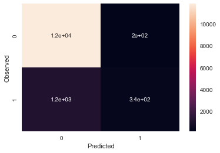

```python
#Create a Confusion Matrix Report for Gradient Boosting
gradientBoosting_conReport = draw_confusion_matrix(y_test, gradientBoosting_predict);
gradientBoosting_conReport.show();
```

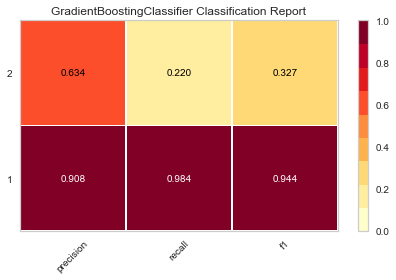

```python
#Create a Classificaiton Report for Gradient Boosting
gradientBoosting_classReport = draw_classification_report(gradientBoosting_model);
gradientBoosting_classReport.show();
```

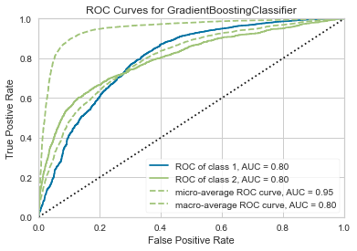

```python
#Create Receiver Operating Characteristic Report for Gradient Boosting
gradientBoosting_rocReport = draw_roc_report(gradientBoosting_model);
gradientBoosting_rocReport.show();
```

### 10. Algorithm Results

#### Model Performance

```python
display(termDeposit_results_data)
```

[output not shown]

#### Algorithm Analysis

Evaluating all the results of all the algorithms points out that the results of all of them, except logistic regression, are all really close to each other. Comparing the precision, recall, F1 score and accuracy are all similar. Both Random Forest and Bagging seemed like they may have been overfitting on the training data compared to the other models as they were higher on the training scores. The other algorithms seemed to have training and testing results that were very similar.

Based on the model performance DataFrame above, I would conclude that the Decision Tree would be the best algorithm for this analysis. The more complex algorithms require more work, time and calculations that typically result in better accuracy but also result in more time to train and run. In this senario, there is virtually no difference, so there is no need or value to incure the cost assocaited with the more advanced algorithms in my opinion. If time was not an issue and the results were substanitally higher with one of the other algorithms, my opinion would be different.